# Normality Detection

Simon Sloan - Alejandro Tirado

## Import dataset Iris

Which is about flowers. First we have to understand the variables the dataset has.

```r
data(iris)

tail(iris)
```

```
##     Sepal.Length Sepal.Width Petal.Length Petal.Width   Species
## 145          6.7         3.3          5.7         2.5 virginica
## 146          6.7         3.0          5.2         2.3 virginica
## 147          6.3         2.5          5.0         1.9 virginica
## 148          6.5         3.0          5.2         2.0 virginica
## 149          6.2         3.4          5.4         2.3 virginica
## 150          5.9         3.0          5.1         1.8 virginica
```

```r
dim(iris)
```

```
## [1] 150   5
```

```r
names(iris)
```

```
## [1] "Sepal.Length" "Sepal.Width"  "Petal.Length" "Petal.Width"  "Species"
```

## Describe dataset

The iris dataset is a well-known dataset in statistics and machine learning that contains measurements of iris flowers from three different species: *setosa*, *versicolor*, and *virginica*.

It consists of 150 observations and 5 variables. The first four variables are quantitative measurements: sepal length, sepal width, petal length, and petal width (all measured in centimeters). The fifth variable is categorical and indicates the species of each flower.

For the purpose of multivariate normality analysis, only the numerical variables are considered, since the Mardia test applies to continuous multivariate data.

Additionally, since the dataset includes observations from different species, it is expected that the assumption of multivariate normality may not hold globally.

[output not shown]

### We have to define S (Covariance Matrix)

```r
    X <- as.matrix(iris[,1:4])
    n <- 150
    p <- 4
    I <- diag(n)
    Jn <- matrix(1, nrow = n, ncol = n)
    Xc <- (I - 1/n*Jn)%*%X
    XcT <- t(Xc)
    S <- 1/n * (XcT%*%Xc)
    # This is the easiest way. However we do it, as before because is better to understand.
    SAuto <- cov(X)
```

### Now, it is important to get Mahalanobis Matrix

This matrix contains the Mahalanobis structure, where the diagonal elements correspond to squared Mahalanobis distances.

```r
    SInvert = solve(S)
    M = Xc%*%SInvert%*%XcT
```

# First lets compute skewness test

## Get b1p

```r
    b1p <- 0

    for (i in 1:nrow(M)) {
        for (j in 1:ncol(M)) {

            element <- (1/(n^2)) * (M[i, j])^3

            b1p <- b1p + element

        }
    }
```

## Get EAS and degress of freedom

```r
    EAS<-(n/6)*b1p
    df<-(1/6)*(p*(p+1)*(p+2))
    pValueSkewness <- pchisq(EAS, df = df, lower.tail = FALSE)
    alpha<-0.05
```

## Now we have obtained the key values for the Mardia Test

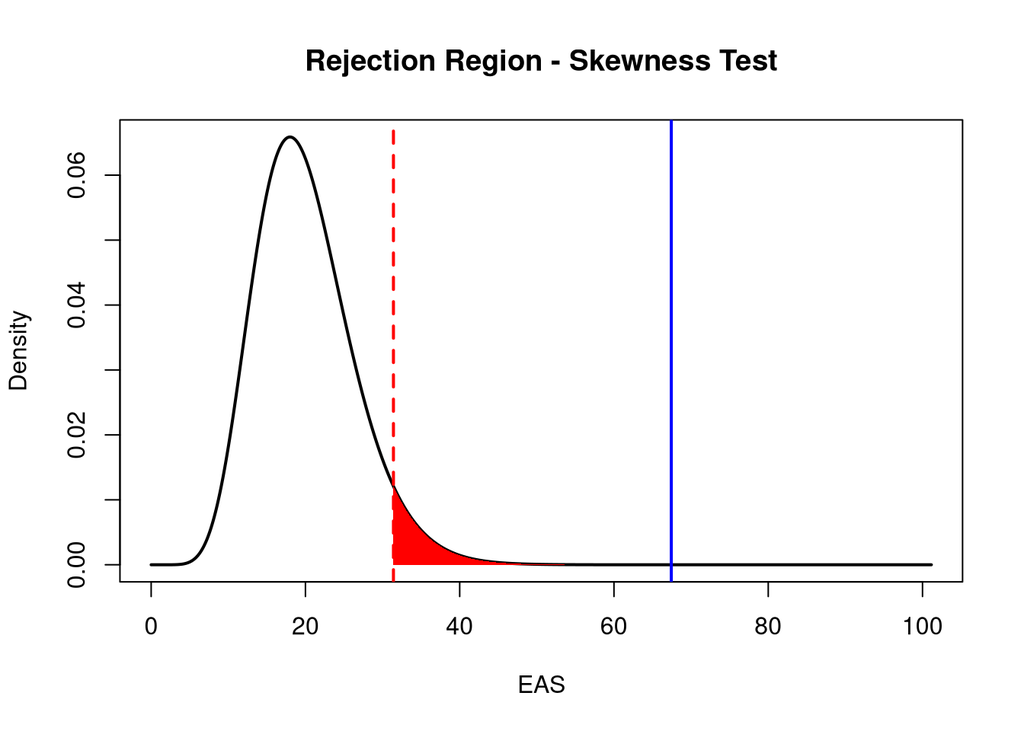

```r
    crit <- qchisq(1 - alpha, df)

    x <- seq(0, max(EAS, crit)*1.5, length=1000)
    y <- dchisq(x, df)

    plot(x, y, type="l", lwd=2, main="Rejection Region - Skewness Test", xlab="EAS", ylab="Density")

    x_rej <- seq(crit, max(x), length=500)
    y_rej <- dchisq(x_rej, df)

    polygon(c(crit, x_rej, max(x)), c(0, y_rej, 0), col="red", border=NA)

    abline(v=crit, col="red", lwd=2, lty=2)
    abline(v=EAS, col="blue", lwd=2)
```

Since the observed value of EAS is greater than the critical value, it falls within the rejection region. Therefore, we reject the null hypothesis of multivariate normality based on the skewness test.

## Why we use p-value and critical value

Both the p-value approach and the critical value approach are equivalent ways to test the same hypothesis. The p-value represents the probability of observing a value as extreme as the test statistic under the null hypothesis. On the other hand, the critical value defines a threshold that separates the acceptance region from the rejection region.

# Lets compute now Kurtosis Test

```r
    b2p <- (1/n) * sum(diag(M)^2)
```

Again, this is just a value. It means that by itself it doesn’t provide a source to reject or not H_0. But is the supply for getting the Test Statistic.

## Now lets compute z

```r
    z <- (b2p - p*(p+2)) / sqrt((8*p*(p+2))/n)
```

In this case, we have now the test statistic Z, which is defined as the difference between b2p (coeficient of kurtosis) and a estimator of Normality divided by and estimator of standard deviation. In other words, it calculates how far is the kurtosis coeficient got from data to the actual estimated kurtosis coeficient that theorically we should have if the data come from a normal distribution. Of course, this value is standarized when we divide by the standard deviation.

## Now lets compute pValue for Kurtosis

```r
    pValueKurtosis <-pchisq(z^2, df = 1, lower.tail = FALSE)
    alpha <-0.05
```

It’s time to reject or not H_0, has you can see we now get the pValueKurtosis which is the probability of observe a extreme value as the obtained, assuming that data comes from a normal distribution. In this case, we obtained a p-value of 0.8180047, which is greater than the significance level 0.05. Therefore, we do not reject the null hypothesis.

## Interpretation

The skewness test produced a p-value of 4.7579982^{-7}, which is smaller than the significance level 0.05. Therefore, the null hypothesis of multivariate normality is rejected.

The kurtosis test produced a p-value of 0.8180047, which is greater than 0.05. Thus, there is no evidence against multivariate kurtosis.

This result suggests that the deviation from normality is primarily driven by asymmetry rather than differences in tail behavior. However, since the skewness test is significant, the assumption of multivariate normality is rejected for the iris dataset according to Mardia’s test. This result is expected because the dataset contains observations from different species populations.